# ECI 589 Unit 3 Independent Analysis

7/30/2021

## PURPOSE >>

- Goals of this analysis
- Background of the data used

## Goals

This network analysis will replicate the methods used in [this walkthrough](https://sbkellogg.github.io/eci-589/unit-3/unit-3-walkthrough-key.html) which itself replicates a network analysis of a longitudinal study that examined school leadership data collected at two school districts over 3 years that was used to answer research questions related to collaboration, efficacy, and trust.

**This analysis will compare the data from year 1 of that same study to uncover some of the ways in which the network may have changed over time.**

## Background

The data is drawn from Daly’s Network of School District Leaders:

> > *“Leadership network data were collected at two school districts over 3 consecutive years. For each consecutive year, school district leaders were invited to complete a survey that collected individual demographic information (e.g., gender, ethnicity, marital status, age, years of experiences), 11 different network relationships (e.g., collaboration, confidential, energy, expertise, support you approach, support approach you, work-related issues, input, recognition, best practices, and innovation), efficacy, and trusting relationships. The social network questions asked the participants to assess the frequency of interactions they have with those nominated individuals on a four-point frequency scale ranging from 1 (the least frequent) to 4 (1–2 times a week). The efficacy items were designed based on the Principal Efficacy Scale used in Daly et al. (2011) and Tschannen-Moran and Gareis’s (2004) studies. The efficacy scale includes 18 items rated on a 9-point Likert scale ranging from 1 (None at all) to 9 (A great deal).The trust scale contains eight items rated on a 7-point Likert scale ranging from 1 (Strongly disagree) to 7 (Strongly agree) modified from Tschannen-Moran and Hoy (2003).”* [source](https://studysites.sagepub.com/carolan/study/resources.htm)

## Data

Specifically, the data sets used for this analysis include:

> S[chool Leaders Data Chapter 9_d.](https://studysites.sagepub.com/carolan/study/materials/datasets/99472_ds10.xls) This adjacency matrix reports on “confidential help” ties among 43 school leaders in year 3 of a three-year study. This is a directed valued (weighted) network measured on five-point scale ranging from 0 to 4, with higher values indicating more frequent collaborations (1–2 times/week). These data are used throughout Chapter 9.

> [School Leaders Data Chapter 9_e.](https://studysites.sagepub.com/carolan/study/materials/datasets/99472_ds11.xlsx) This rectangular matrix consists of four attribute vectors for 43 school leaders. Following the first ID column, the matrix includes an efficacy score, trust score, and indicators for whether one works at the district-level and is male (1 = yes, 0 = no). These attribute variables can be used as covariates in some of the statistical models covered in Chapter 9, including regression and p* models.

## METHODS >>

- Tools used
- Getting our data ready to analyze

## Libraries used

The R packages used for this analysis include…

`library(readxl)` - to read in le data

`library(tidyverse)` - to tidy le text

`library(igraph)` - to create visualizations

`library(tidygraph)` - to create create visualizations

`library(ggraph)` - to create visualizations

`library(statnet)` - to do some statistical modeling

## Data import

First, we have to import our data.

```r
## nodes = demographic info
leader_nodes <- read_excel("data/School Leaders Data Chapter 9_e.xlsx",
                    col_types = c("text", "numeric", "numeric", "numeric", "numeric"))

## relationships from year 1
leader_matrix_1 <- read_excel("data/School Leaders Data Chapter 9_c.xlsx",
                              col_names = FALSE)

## relationships from year 3
leader_matrix_3 <- read_excel("data/School Leaders Data Chapter 9_d.xlsx",
                            col_names = FALSE)
```

## Dichotomize the matrix

Next, we have to dichotomize the matrix, a phrase which would make a really cool metal band name but here essentially means turning everything into a binary code that indicates the presence or absence of a relationship:

```r
# year 1

#making things into a matrix r will recognize
leader_matrix_1 <- leader_matrix_1 %>%
  as.matrix()

#dichotomize! change 2s to 0s and 3s to 1s
leader_matrix_1[leader_matrix_1 <= 2] <- 0
leader_matrix_1[leader_matrix_1 >= 3] <- 1

#rename some things so we can get our edges in a bit
rownames(leader_matrix_1) <- leader_nodes$ID
colnames(leader_matrix_1) <- leader_nodes$ID
```

## #gotedges?

Next, we have to get our edges (or, in plain English, all that info related to the ties, or relationships between individual leaders represented in the data set):

```
## # A tbl_graph: 43 nodes and 25 edges
## #
## # A directed simple graph with 21 components
## #
## # Node Data: 43 × 5 (active)
##   ID    EFFICACY TRUST `DISTRICT/SITE`  MALE
##   <chr>    <dbl> <dbl>           <dbl> <dbl>
## 1 1         6.06  4                  1     0
## 2 2         6.56  5.63               1     0
## 3 3         7.39  4.63               1     0
## 4 4         4.89  4                  1     0
## 5 5         6.06  5.75               0     1
## 6 6         7.39  4.38               0     0
## # … with 37 more rows
## #
## # Edge Data: 25 × 2
##    from    to
##   <int> <int>
## 1     7    33
## 2     9     5
## 3     9    17
## # … with 22 more rows
```

## FINDINGS >>

- A look at degrees
- Basic descriptive stats
- Statistical modeling

## In vs. Out Degree & Other Summary Stats

> > *“Recall degree is the number of ties to and from an ego. In a directed network, in-degree is the number of ties received, whereas out-degree is the number of ties sent.”*
- > > So, in this case: how many times a school leader turns to someone else for advice vs. how many times someone turns to them for advice.

We can also calculate our overall summary stats for the efficacy & trust scores here too, which are coming from our rectangular nodes matrix and so will remain constant between the two years being compared.

## …calculating…

```r
# adding for year 1
leader_measures_1 <- leader_graph_1 %>%
  activate(nodes) %>%
  mutate(in_degree = centrality_degree(mode = "in")) %>%
  mutate(out_degree = centrality_degree(mode = "out"))

# adding for year 3
leader_measures_3 <- leader_graph_3 %>%
  activate(nodes) %>%
  mutate(in_degree = centrality_degree(mode = "in")) %>%
  mutate(out_degree = centrality_degree(mode = "out"))
```

## Summary stats yr. 1

```
##       ID               EFFICACY         TRUST       DISTRICT.SITE
##  Length:43          Min.   :4.610   Min.   :3.630   Min.   :0.0000
##  Class :character   1st Qu.:5.670   1st Qu.:4.130   1st Qu.:0.0000
##  Mode  :character   Median :6.780   Median :4.780   Median :0.0000
##                     Mean   :6.649   Mean   :4.783   Mean   :0.4186
##                     3rd Qu.:7.470   3rd Qu.:5.440   3rd Qu.:1.0000
##                     Max.   :8.500   Max.   :5.880   Max.   :1.0000
##       MALE          in_degree        out_degree
##  Min.   :0.0000   Min.   :0.0000   Min.   :0.0000
##  1st Qu.:0.0000   1st Qu.:0.0000   1st Qu.:0.0000
##  Median :0.0000   Median :0.0000   Median :0.0000
##  Mean   :0.4419   Mean   :0.5814   Mean   :0.5814
##  3rd Qu.:1.0000   3rd Qu.:1.0000   3rd Qu.:1.0000
##  Max.   :1.0000   Max.   :4.0000   Max.   :2.0000
```

## Summary stats yr. 3

```
##       ID               EFFICACY         TRUST       DISTRICT.SITE
##  Length:43          Min.   :4.610   Min.   :3.630   Min.   :0.0000
##  Class :character   1st Qu.:5.670   1st Qu.:4.130   1st Qu.:0.0000
##  Mode  :character   Median :6.780   Median :4.780   Median :0.0000
##                     Mean   :6.649   Mean   :4.783   Mean   :0.4186
##                     3rd Qu.:7.470   3rd Qu.:5.440   3rd Qu.:1.0000
##                     Max.   :8.500   Max.   :5.880   Max.   :1.0000
##       MALE          in_degree       out_degree
##  Min.   :0.0000   Min.   :0.000   Min.   : 0.000
##  1st Qu.:0.0000   1st Qu.:2.000   1st Qu.: 1.000
##  Median :0.0000   Median :3.000   Median : 2.000
##  Mean   :0.4419   Mean   :3.326   Mean   : 3.326
##  3rd Qu.:1.0000   3rd Qu.:5.000   3rd Qu.: 4.000
##  Max.   :1.0000   Max.   :8.000   Max.   :20.000
```

## Visualize the network

Next, we’ll create some network visualizations to help us more easily compare year 1 with year 3.

[figure not shown]

## Year 1 network

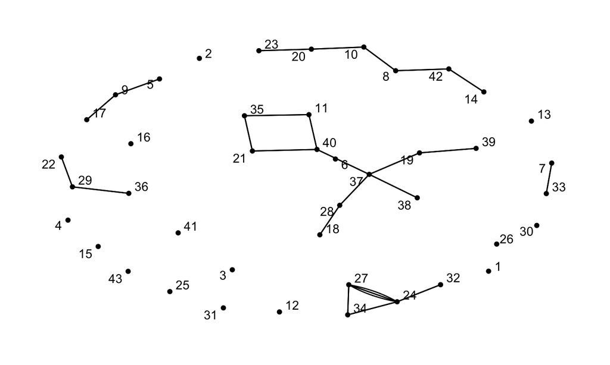

## Year 3 network

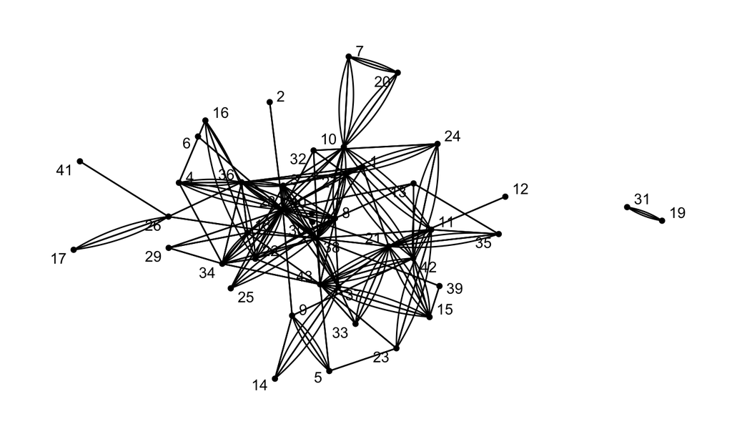

## ERGMs

Creating a visualization like that is only part of the picture – we can go deeper by way of ERGMs:

> > *“Exponential Random Graph Models provide a means to compare whether a network’s observed structural properties occur more frequently than you could expect from chance alone”*

First, we have to load our network data >>

## Loading network data

```r
# yr 1
leader_network_1 <- as.network(leader_edges_1,
                             vertices = leader_nodes)

# yr 3
leader_network_3 <- as.network(leader_edges_3,
                             vertices = leader_nodes)
```

## Estimate the model

Next, we estimate the model, accounting for mutuality.

[figure not shown]

## Estimating Year 1:

```
##  edges mutual
##     25      1
```

```
## Call:
## ergm(formula = leader_network_1 ~ edges + mutual)
##
## Monte Carlo Maximum Likelihood Results:
##
##        Estimate Std. Error MCMC % z value Pr(>|z|)
## edges    -4.324      0.209      0 -20.688   <1e-04 ***
## mutual    2.022      1.156      0   1.749   0.0802 .
## ---
## Signif. codes:  0 '***' 0.001 '**' 0.01 '*' 0.05 '.' 0.1 ' ' 1
##
##      Null Deviance: 2503.6  on 1806  degrees of freedom
##  Residual Deviance:  261.7  on 1804  degrees of freedom
##
## AIC: 265.7  BIC: 276.7  (Smaller is better. MC Std. Err. = 0.1306)
```

```
##            edges           mutual       transitive gwesp.fixed.0.25
##               25                1                2                2
```

## Estimating Year 3:

```
##  edges mutual
##    143     36
```

```
## Call:
## ergm(formula = leader_network_3 ~ edges + mutual)
##
## Monte Carlo Maximum Likelihood Results:
##
##        Estimate Std. Error MCMC % z value Pr(>|z|)
## edges   -3.1158     0.1269      0  -24.56   <1e-04 ***
## mutual   3.1164     0.3018      0   10.33   <1e-04 ***
## ---
## Signif. codes:  0 '***' 0.001 '**' 0.01 '*' 0.05 '.' 0.1 ' ' 1
##
##      Null Deviance: 2503.6  on 1806  degrees of freedom
##  Residual Deviance:  892.7  on 1804  degrees of freedom
##
## AIC: 896.7  BIC: 907.7  (Smaller is better. MC Std. Err. = 1.307)
```

```
##            edges           mutual       transitive gwesp.fixed.0.25
##         143.0000          36.0000         202.0000         116.2971
```

[output not shown]

## Adding transitivity

Wherein transitivity = the “friend of a friend” phenomenon. Think: triads.

[figure not shown]

## Transitivity yr. 1

```
## Call:
## ergm(formula = leader_network_1 ~ edges + mutual + gwesp(0.25,
##     fixed = T))
##
## Monte Carlo Maximum Likelihood Results:
##
##                  Estimate Std. Error MCMC % z value Pr(>|z|)
## edges             -4.4360     0.2055      0 -21.587  < 1e-04 ***
## mutual             1.3196     1.1360      0   1.162 0.245390
## gwesp.fixed.0.25   1.5732     0.4457      0   3.530 0.000416 ***
## ---
## Signif. codes:  0 '***' 0.001 '**' 0.01 '*' 0.05 '.' 0.1 ' ' 1
##
##      Null Deviance: 2504  on 1806  degrees of freedom
##  Residual Deviance:  258  on 1803  degrees of freedom
##
## AIC: 264  BIC: 280.5  (Smaller is better. MC Std. Err. = 0.2551)
```

## Transitivity yr. 3

```
## Call:
## ergm(formula = leader_network_3 ~ edges + mutual + gwesp(0.25,
##     fixed = T))
##
## Monte Carlo Maximum Likelihood Results:
##
##                  Estimate Std. Error MCMC % z value Pr(>|z|)
## edges             -3.9694     0.1506      0 -26.351   <1e-04 ***
## mutual             2.2951     0.2970      0   7.729   <1e-04 ***
## gwesp.fixed.0.25   1.0669     0.1273      0   8.380   <1e-04 ***
## ---
## Signif. codes:  0 '***' 0.001 '**' 0.01 '*' 0.05 '.' 0.1 ' ' 1
##
##      Null Deviance: 2503.6  on 1806  degrees of freedom
##  Residual Deviance:  807.1  on 1803  degrees of freedom
##
## AIC: 813.1  BIC: 829.6  (Smaller is better. MC Std. Err. = 0.9894)
```

## Actor level attributes

We saw in the walkthorugh that we can also add in actor level attributes, which can allow us to compare covariates. Put more simply: we can factor in demographic and behavioral variables.

The following, for example, is what we used to tell us whether those who are Male or have higher efficacy scores are more likely to either send or receive at tie. And the answer here was that while there was a slight indication that male leaders might be more likely to send or receive ties, things like reciprocity and transitivity had more of an impact on the overall network >>

## Year 3 actor level attributes

```
## Call:
## ergm(formula = leader_network_3 ~ edges + mutual + gwesp(0.25,
##     fixed = T) + nodefactor("MALE") + nodecov("EFFICACY"))
##
## Monte Carlo Maximum Likelihood Results:
##
##                   Estimate Std. Error MCMC % z value Pr(>|z|)
## edges             -4.37755    0.42795      0 -10.229   <1e-04 ***
## mutual             2.29865    0.31079      0   7.396   <1e-04 ***
## gwesp.fixed.0.25   1.05331    0.13030      0   8.084   <1e-04 ***
## nodefactor.MALE.1  0.10759    0.06557      0   1.641    0.101
## nodecov.EFFICACY   0.02397    0.03021      0   0.794    0.427
## ---
## Signif. codes:  0 '***' 0.001 '**' 0.01 '*' 0.05 '.' 0.1 ' ' 1
##
##      Null Deviance: 2503.6  on 1806  degrees of freedom
##  Residual Deviance:  802.8  on 1801  degrees of freedom
##
## AIC: 812.8  BIC: 840.3  (Smaller is better. MC Std. Err. = 0.7271)
```

## Year 1 actor level attributes (???)

Attempting to run that very same analysis on the year 1 data, however, leads to the following error >>

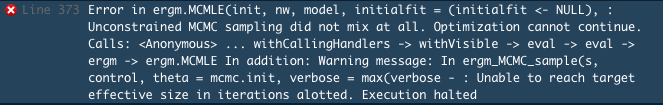

Cursory Google searches have not proved helpful in determinging the cause of this error, but if I had to guess there is some sort of failure to converge here. Perhaps the limited nature of the year 1 data, with its fewer edges, isn’t enough for this calculation to go off of? At any rate, there has been enough analysis nonetheless for some fruitful discussion >>

## DISCUSSION >>

- comparing degree
- comparing network diagrams
- comparing ERGMs

## Comparison – degree

In terms of **in-degree vs. out-degree** for year 1 >> year 3:

- It looks like on average in year 1 in-degree was 0.5814, compared to 3.326 in year 3.
- And out-degree on average in year 1 was also 0.5814, compared to 3.326 in year 3.

Essentially, the leaders represented in this dataset went from being connected (on average) to half a person at the beginning of the study, to being connect to at least 3 and a third of a person towards the end. These results are not at all surprising for a longitudinal study, and indicate that the network became more cohesive over time.

## Comparison – network diagrams

In looking at the year one vs. year three network diagrams, there are some marked differences.

Clearly, at the start of the study, there were some confidential exchanges going on – but not nearly to the degree that they were in year 3.

## Comparison – ERGMs

ERGMs help us to determine whether or not the observed network has occurred by happenstance or if there is something greater than chance alone at play.

## Comparison – ERGMs

Recalling from the year 3 analysis, wherein our edges estimate was -3.12 and our mutuality estimate was also 3.12:

> > *"the estimates for our edges and mutual terms are statistically significant. The negative estimate for the edge parameter, as noted by Carolan (2014), implies that the probability of a confidential exchange tie in year 3 is relatively low. The reciprocity parameter, on the other hand, is 3.11 in our model, and indicates a strong tendency for confidential-exchange ties to be reciprocated.*

## Comparison – ERGMs

We also saw slightly more transitivity in year 1 (1.57) than in year 3 (1.07), which is honestly the opposite of what I would expect given that the network became a lot more cohesive over time (but it was also not a large or significant change).

## In Summary:

The changes between year 1 and year 3 were marked. Our degree measures, network diagrams, and ERGMs indicated that the network became more cohesive over time, and actor level attributes did not seem to be playing a significant role. This points to a conclusion that whatever intervention was levied between year 1 and 3 of this study was effective in getting more school leaders to talk to/confide in one another. In the case of attempting to pass new educational policy, this is an achievement and such findings would be worth paying attention to and examining further.